# Association Rules - Week 14

Roselynn

1/22/2021

# 1.Loading the Packages and Importing the Dataset

I loaded the tidyverse package and the arules package

```r
library(arules)
library(tidyverse)
```

I imported the dataset using the read.transactions() function

```r
# Importing the Dataset

dataset <- read.transactions("http://bit.ly/SupermarketDatasetII" ,
                                   sep =",")
#View(dataset)
```

I used the summary function to obtain the summary statisics of the dataset.

```r
summary(dataset)
```

```
## transactions as itemMatrix in sparse format with
##  7501 rows (elements/itemsets/transactions) and
##  119 columns (items) and a density of 0.03288973
##
## most frequent items:
## mineral water          eggs     spaghetti  french fries     chocolate
##          1788          1348          1306          1282          1229
##       (Other)
##         22405
##
## element (itemset/transaction) length distribution:
## sizes
##    1    2    3    4    5    6    7    8    9   10   11   12   13   14   15   16
## 1754 1358 1044  816  667  493  391  324  259  139  102   67   40   22   17    4
##   18   19   20
##    1    2    1
##
##    Min. 1st Qu.  Median    Mean 3rd Qu.    Max.
##   1.000   2.000   3.000   3.914   5.000  20.000
##
## includes extended item information - examples:
##              labels
## 1           almonds
## 2 antioxydant juice
## 3         asparagus
```

The dataset had 119 items with 7501 itemsets with the most frequently purchased item being mineral water.

I then previewed the first ten itemsets using the inspect function

```r
inspect(dataset[1:10])
```

```
##      items
## [1]  {almonds,
##       antioxydant juice,
##       avocado,
##       cottage cheese,
##       energy drink,
##       frozen smoothie,
##       green grapes,
##       green tea,
##       honey,
##       low fat yogurt,
##       mineral water,
##       olive oil,
##       salad,
##       salmon,
##       shrimp,
##       spinach,
##       tomato juice,
##       vegetables mix,
##       whole weat flour,
##       yams}
## [2]  {burgers,
##       eggs,
##       meatballs}
## [3]  {chutney}
## [4]  {avocado,
##       turkey}
## [5]  {energy bar,
##       green tea,
##       milk,
##       mineral water,
##       whole wheat rice}
## [6]  {low fat yogurt}
## [7]  {french fries,
##       whole wheat pasta}
## [8]  {light cream,
##       shallot,
##       soup}
## [9]  {frozen vegetables,
##       green tea,
##       spaghetti}
## [10] {french fries}
```

I also previewed the items in my dataset.

```r
items <- as.data.frame(itemLabels(dataset))
colnames(items) <- "Item"
head(items, 10)
```

```
##                 Item
## 1            almonds
## 2  antioxydant juice
## 3          asparagus
## 4            avocado
## 5        babies food
## 6              bacon
## 7     barbecue sauce
## 8          black tea
## 9        blueberries
## 10        body spray
```

```r
tail(items,10)
```

```
##                  Item
## 110            turkey
## 111    vegetables mix
## 112       water spray
## 113        white wine
## 114  whole weat flour
## 115 whole wheat pasta
## 116  whole wheat rice
## 117              yams
## 118       yogurt cake
## 119          zucchini
```

I then inspected the frequency of the first 15 items in my dataset.

```r
itemFrequency(dataset[, 1:15],type = "absolute")
```

```
##           almonds antioxydant juice         asparagus           avocado
##               153                67                36               250
##       babies food             bacon    barbecue sauce         black tea
##                34                65                81               107
##       blueberries        body spray           bramble          brownies
##                69                86                14               253
##         bug spray      burger sauce           burgers
##                65                44               654
```

I plotted the top 20 most frequent items in the dataset using the ItemFrequency and topN.

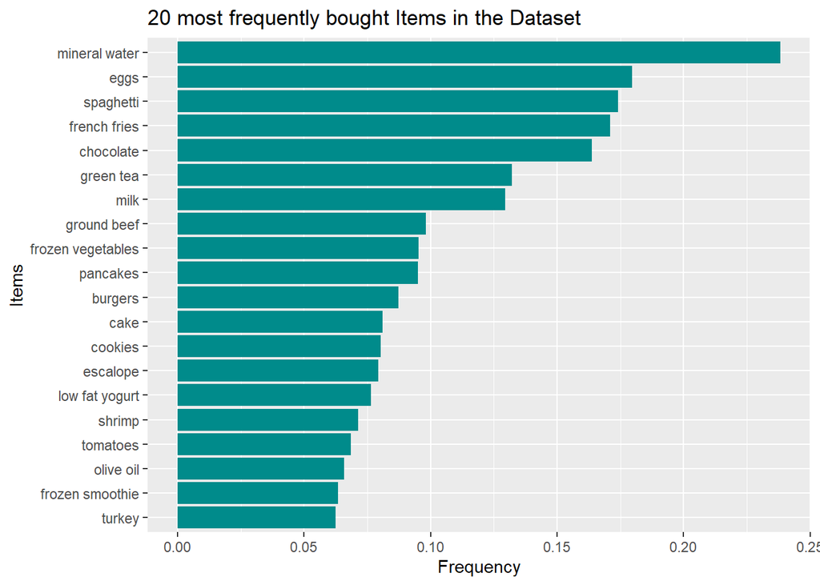

```r
itemFrequencyGGPlot <- function(x, topN) {
  library(tidyverse)
  x %>%
    itemFrequency %>%
    sort %>%
    tail(topN) %>%
    as.data.frame %>%
    tibble::rownames_to_column() %>%
    ggplot(aes(reorder(rowname, `.`),`.`)) +
    geom_col(fill='cyan4') + labs(title='20 most frequently bought Items in the Dataset' , y  = "Frequency" , x = 'Items')+
    coord_flip()
}
itemFrequencyGGPlot(dataset, 20)
```

The most frequent label within the whole dataset was the Mineral water , followed by eggs.

# Association Rules

I then obtained the rules of the dataset using the apriori() function.

```r
rules <- apriori (dataset, parameter = list(supp = 0.001, conf = 0.6))
```

```
## Apriori
##
## Parameter specification:
##  confidence minval smax arem  aval originalSupport maxtime support minlen
##         0.6    0.1    1 none FALSE            TRUE       5   0.001      1
##  maxlen target  ext
##      10  rules TRUE
##
## Algorithmic control:
##  filter tree heap memopt load sort verbose
##     0.1 TRUE TRUE  FALSE TRUE    2    TRUE
##
## Absolute minimum support count: 7
##
## set item appearances ...[0 item(s)] done [0.00s].
## set transactions ...[119 item(s), 7501 transaction(s)] done [0.01s].
## sorting and recoding items ... [116 item(s)] done [0.00s].
## creating transaction tree ... done [0.01s].
## checking subsets of size 1 2 3 4 5 6 done [0.03s].
## writing ... [545 rule(s)] done [0.00s].
## creating S4 object  ... done [0.01s].
```

```r
rules
```

```
## set of 545 rules
```

I then used the inspect function to see the first 10 rules of my dataset

```r
inspect(rules[1:10])
```

```
##      lhs                          rhs              support     confidence
## [1]  {cookies,shallot}         => {low fat yogurt} 0.001199840 0.6000000
## [2]  {low fat yogurt,shallot}  => {cookies}        0.001199840 0.6923077
## [3]  {cookies,shallot}         => {green tea}      0.001199840 0.6000000
## [4]  {cookies,shallot}         => {french fries}   0.001199840 0.6000000
## [5]  {low fat yogurt,shallot}  => {french fries}   0.001066524 0.6153846
## [6]  {burger sauce,chicken}    => {mineral water}  0.001066524 0.6666667
## [7]  {frozen smoothie,spinach} => {mineral water}  0.001066524 0.8888889
## [8]  {milk,spinach}            => {mineral water}  0.001066524 0.6666667
## [9]  {spaghetti,spinach}       => {mineral water}  0.001333156 0.7142857
## [10] {olive oil,strong cheese} => {spaghetti}      0.001066524 0.7272727
##      coverage    lift     count
## [1]  0.001999733 7.840767  9
## [2]  0.001733102 8.611940  9
## [3]  0.001999733 4.541473  9
## [4]  0.001999733 3.510608  9
## [5]  0.001733102 3.600624  8
## [6]  0.001599787 2.796793  8
## [7]  0.001199840 3.729058  8
## [8]  0.001599787 2.796793  8
## [9]  0.001866418 2.996564 10
## [10] 0.001466471 4.177085  8
```

Similarly I did the same for the last ten rules

```r
inspect(rules[535:545])
```

```
##      lhs                    rhs                     support confidence    coverage     lift count
## [1]  {chocolate,
##       frozen vegetables,
##       ground beef,
##       milk}              => {spaghetti}         0.001599787  0.6000000 0.002666311 3.446095    12
## [2]  {chocolate,
##       frozen vegetables,
##       ground beef,
##       milk}              => {mineral water}     0.001999733  0.7500000 0.002666311 3.146393    15
## [3]  {chocolate,
##       frozen vegetables,
##       ground beef,
##       mineral water}     => {milk}              0.001999733  0.6000000 0.003332889 4.630247    15
## [4]  {chocolate,
##       ground beef,
##       milk,
##       mineral water}     => {frozen vegetables} 0.001999733  0.6000000 0.003332889 6.294545    15
## [5]  {eggs,
##       frozen vegetables,
##       ground beef,
##       milk}              => {mineral water}     0.001466471  0.6875000 0.002133049 2.884193    11
## [6]  {frozen vegetables,
##       ground beef,
##       milk,
##       spaghetti}         => {mineral water}     0.001866418  0.6086957 0.003066258 2.553594    14
## [7]  {chocolate,
##       eggs,
##       frozen vegetables,
##       ground beef}       => {mineral water}     0.001466471  0.8461538 0.001733102 3.549776    11
## [8]  {eggs,
##       frozen vegetables,
##       milk,
##       spaghetti}         => {mineral water}     0.001733102  0.6500000 0.002666311 2.726874    13
## [9]  {chocolate,
##       frozen vegetables,
##       ground beef,
##       milk,
##       spaghetti}         => {mineral water}     0.001066524  0.6666667 0.001599787 2.796793     8
## [10] {chocolate,
##       frozen vegetables,
##       ground beef,
##       mineral water,
##       spaghetti}         => {milk}              0.001066524  0.6153846 0.001733102 4.748971     8
## [11] {chocolate,
##       ground beef,
##       milk,
##       mineral water,
##       spaghetti}         => {frozen vegetables} 0.001066524  0.8888889 0.001199840 9.325253     8
```

I used the quality() function to check the quality of the rules of my model.

```r
head(quality(rules))
```

```
##       support confidence    coverage     lift count
## 1 0.001199840  0.6000000 0.001999733 7.840767     9
## 2 0.001199840  0.6923077 0.001733102 8.611940     9
## 3 0.001199840  0.6000000 0.001999733 4.541473     9
## 4 0.001199840  0.6000000 0.001999733 3.510608     9
## 5 0.001066524  0.6153846 0.001733102 3.600624     8
## 6 0.001066524  0.6666667 0.001599787 2.796793     8
```

```r
tail(quality(rules))
```

```
##         support confidence    coverage     lift count
## 540 0.001866418  0.6086957 0.003066258 2.553594    14
## 541 0.001466471  0.8461538 0.001733102 3.549776    11
## 542 0.001733102  0.6500000 0.002666311 2.726874    13
## 543 0.001066524  0.6666667 0.001599787 2.796793     8
## 544 0.001066524  0.6153846 0.001733102 4.748971     8
## 545 0.001066524  0.8888889 0.001199840 9.325253     8
```

# Visualizing association rules using the arulesviz package

```
## To reduce overplotting, jitter is added! Use jitter = 0 to prevent jitter.
```

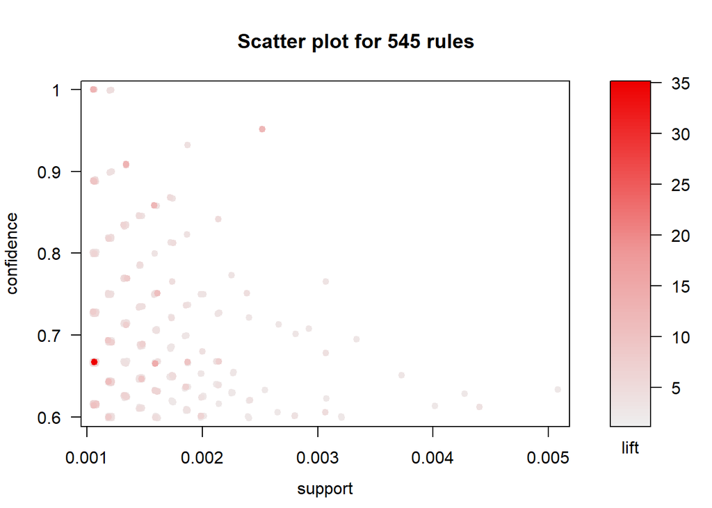

```r
#install.packages("arulesViz")
library(arulesViz)
## Scatterplot with custom colors
library(colorspace)
# for sequential_hcl
plot(rules)
```

I noted that there was one rule with high lift , it also had low confidence and low support

```r
subrules <- head(rules, n = 30, by = "confidence")

plot(subrules, method = "graph" ,   engine = "htmlwidget")
```

[interactive chart not shown]

I also plotted the graph , with the default engine. Many arrows tend to point towards the Mineral water , meaning many of the purchases were associated with the purchase of mineral water.

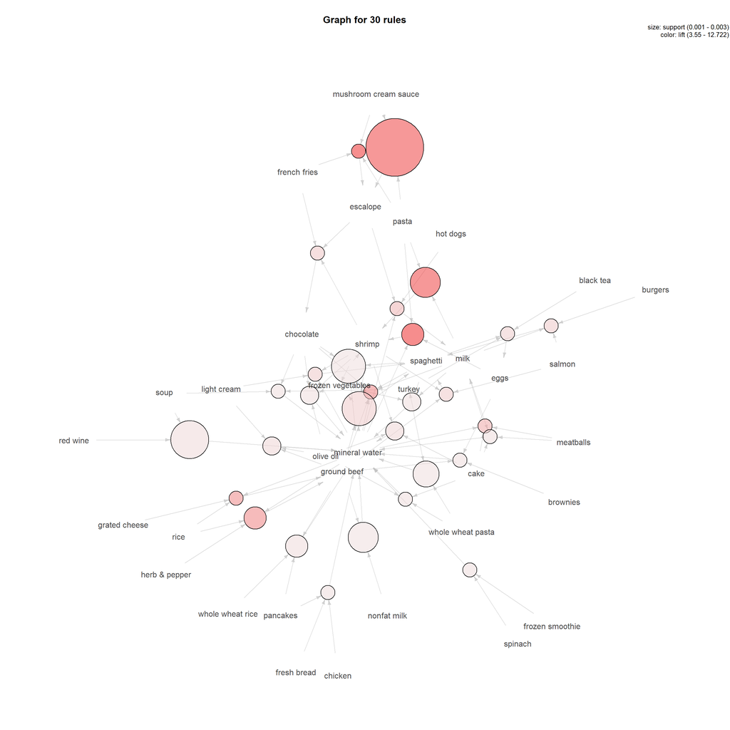

```r
plot(subrules, method = "graph" ,   engine = "default")
```

I also used the paracoord method to plot out my subrules

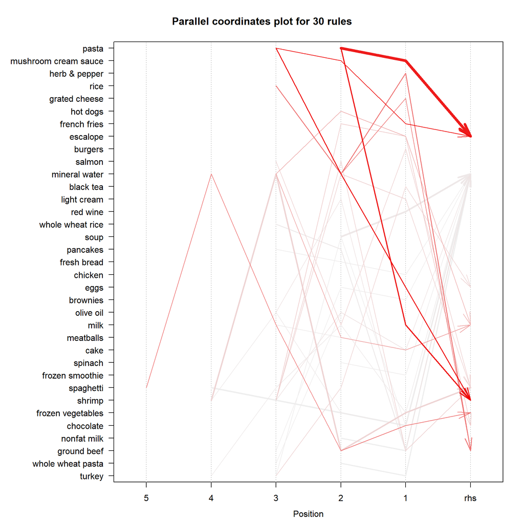

```r
plot(subrules, method = "paracoord")
```

Finally I plotted my subrules with the grouped method

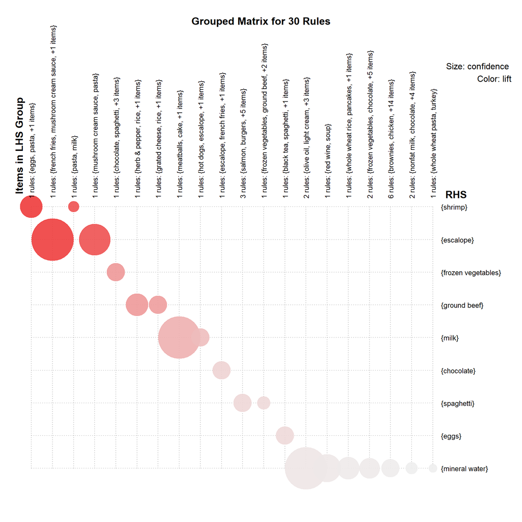

```r
## 2D matrix with shading
plot(subrules,method="grouped", measure="confidence", engine ="default" )
```

# Summary

From my grouped plot I noted that Mineral water had an association with many of the items , for instance from this plot above it had : + 1 rule with whole wheat , pasta and turkey with low lift and low confidence. + 2 rules with nonfat milk , chocolate and four other items with low lift and low confidence. + 6 rules with brownies , chicken and 14 other items , with low lift and low confidence.

The rules with the highest confidence were :

- Olive oil , light cream with three other items and mineral water.
- Meatball , cake and one other item with milk
- Mushroom Cream Sauce and Pasta with escalope
- Mushroom Cream Sauce , French fries and one other item with escalope

The rules with high lift were :

- Eggs , Pasta and one other item with shrimp
- Mushroom Cream Sauce , French fries and one other item with escalope
- Pasta , milk with shrimp
- Mushroom Cream Sauce and Pasta with escalope

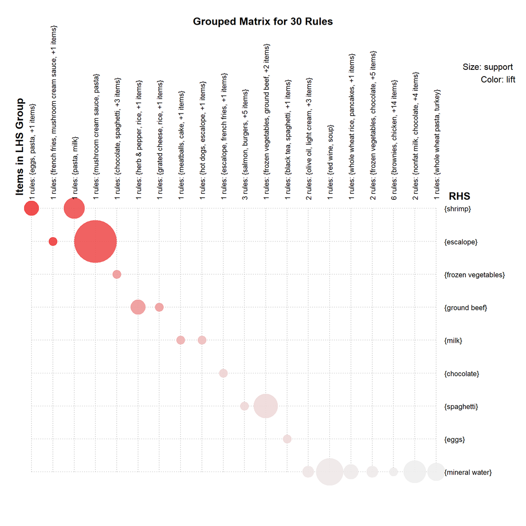

```r
## 2D matrix with shading
plot(subrules,method="grouped", measure="support", engine ="default" )
```

I plotted the same graph , using the support in place of the confidence and similar results can be echoed here.